- Back to index

# Survival curves of mothers returning work

## Variable: PL210x - Main activity by month

The key variale [PL210A - Main activity on January](http://www.gesis.org/?id=8063#PL210A) has following values

Table: Values and labels of var PL210A - Main activity on January

| Value | Label |
| --- | --- |
| 1 | Employee (full-time) |
| 2 | Employee (part-time) |
| 3 | Self-employed (full-time) |
| 4 | Self-employed (part-time) |
| 5 | unemployed |
| 6 | Retired |
| 7 | Student |
| 8 | Other inactive |

Below are plotted all the values as stacked bars from all the months of the data

### All the European mothers

[output not shown]

[output not shown]

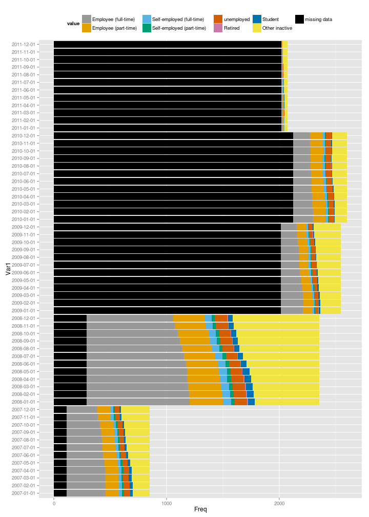

### Mothers by country

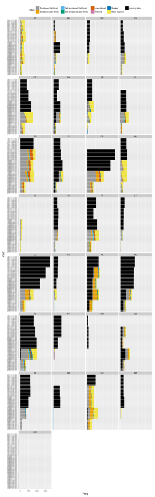

**Some notes**

- Data is perfect from some countries and useless in others
- From the latest years it is basically missing

Previously I subsetted certain countries (excluding nordic for instance), but now I have included all the countries AND all the years.

## creating a survival data.frame

[CRAN Task View: Survival Analysis](http://cran.r-project.org/web/views/Survival.html) works as a starting point.

> Survival analysis, also called event history analysis in social science, or reliability analysis in engineering, deals with time until occurrence of an event of interest. However, this failure time may not be observed within the relevant time period, producing so-called censored observations.

> This task view aims at presenting the useful R packages for the analysis of time to event data.

### Filtering countries & years with missing data

And get this data.

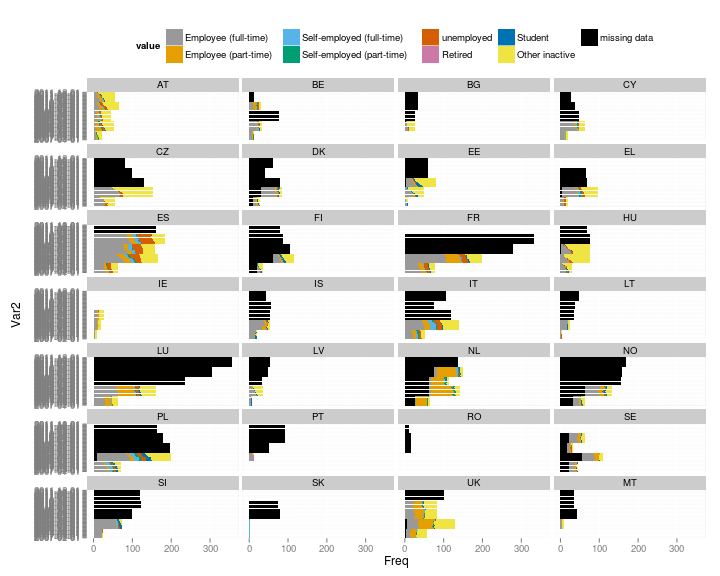

### Discrete time data

We assume that mothers on welfare benefits belong to group 8 (Other inactive) and therefore an event would change over to value 1:4 (employee/self-employed - full/part-time)

### Length of maternity leave spells

# Survival tables & curves

## Mean duration between exiting work to entering work (maternal leave)

[output not shown]

## Survival curves by regimes

First the tables

```
## Call: survfit(formula = Surv(df.long4$duration, df.long4$event) ~ df.long4$regime)
##
## 16 observations deleted due to missingness
##                 df.long4$regime=Central Europe
##  time n.risk n.event survival std.err lower 95% CI upper 95% CI
##     2     33       2    0.939  0.0415        0.861        1.000
##     3     31       2    0.879  0.0568        0.774        0.998
##     4     29       2    0.818  0.0671        0.697        0.961
##     6     27       1    0.788  0.0712        0.660        0.940
##    12     26       1    0.758  0.0746        0.625        0.919
##
##                 df.long4$regime=Liberal
##  time n.risk n.event survival std.err lower 95% CI upper 95% CI
##     1     11       2    0.818   0.116       0.6192        1.000
##     5      9       1    0.727   0.134       0.5064        1.000
##     6      8       5    0.273   0.134       0.1039        0.716
##     7      3       1    0.182   0.116       0.0519        0.637
##
##                 df.long4$regime=Nordic
##  time n.risk n.event survival std.err lower 95% CI upper 95% CI
##     1     18       1    0.944  0.0540        0.844        1.000
##     5     17       2    0.833  0.0878        0.678        1.000
##     8     15       3    0.667  0.1111        0.481        0.924
##    16     12       1    0.611  0.1149        0.423        0.883
##    17     11       1    0.556  0.1171        0.368        0.840
##
##                 df.long4$regime=Post Soc
##         time       n.risk      n.event     survival      std.err
##       9.0000      46.0000       1.0000       0.9783       0.0215
## lower 95% CI upper 95% CI
##       0.9370       1.0000
##
##                 df.long4$regime=Southern Europe
##  time n.risk n.event survival std.err lower 95% CI upper 95% CI
##     1     14       1    0.929  0.0688        0.803        1.000
##     3     13       1    0.857  0.0935        0.692        1.000
##     6     12       1    0.786  0.1097        0.598        1.000
##    10     11       1    0.714  0.1207        0.513        0.995
##    13     10       1    0.643  0.1281        0.435        0.950
```

And the preliminary plot

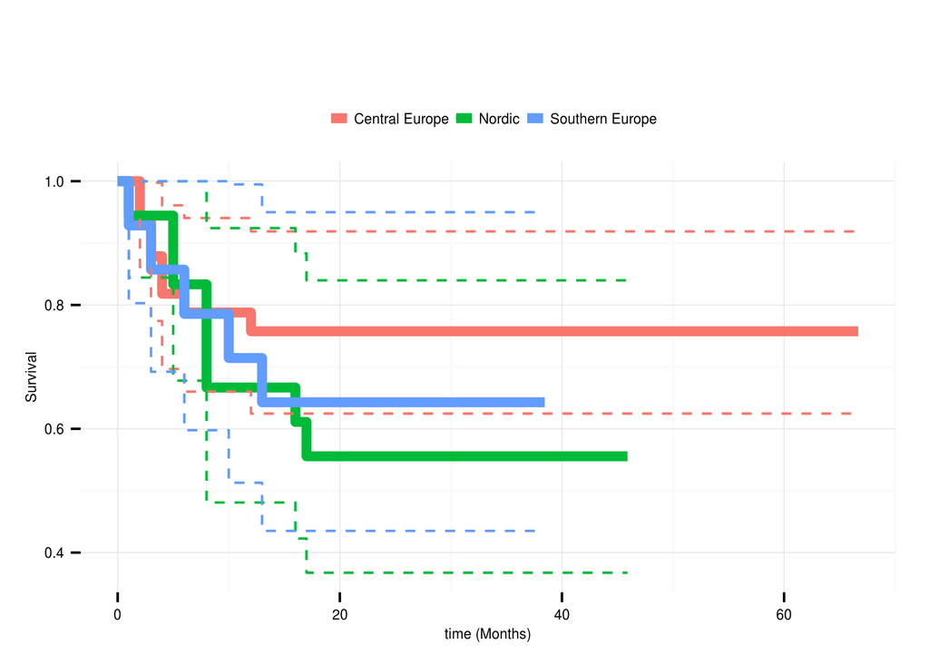

Load for Ms Word